# Proyecto_MASTER_

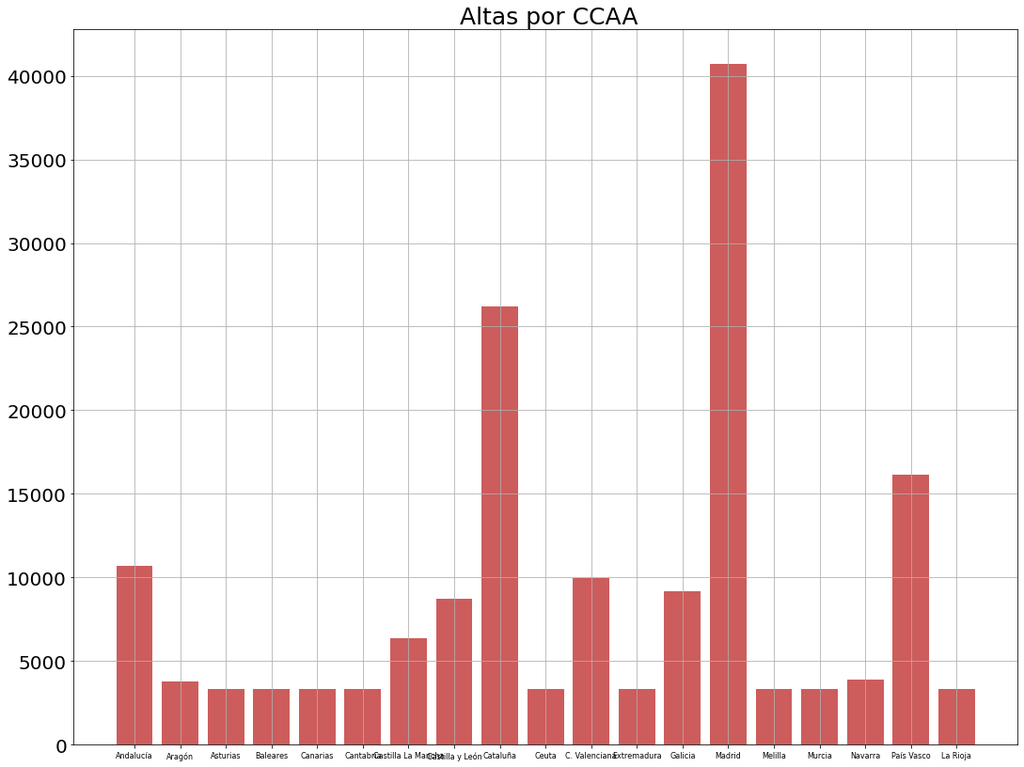

```python
graficas(altas.CCAA,altas.total," Altas por CCAA")
```

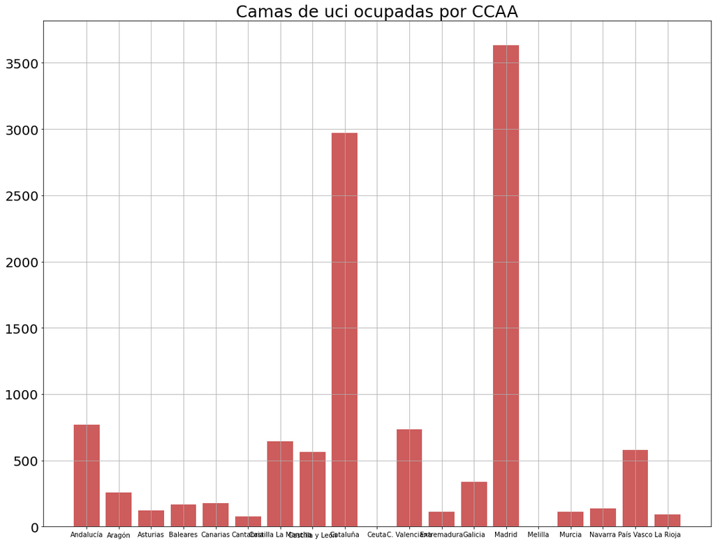

```python
graficas(camas_uci.CCAA,camas_uci.total, "Camas de uci ocupadas por CCAA")
```

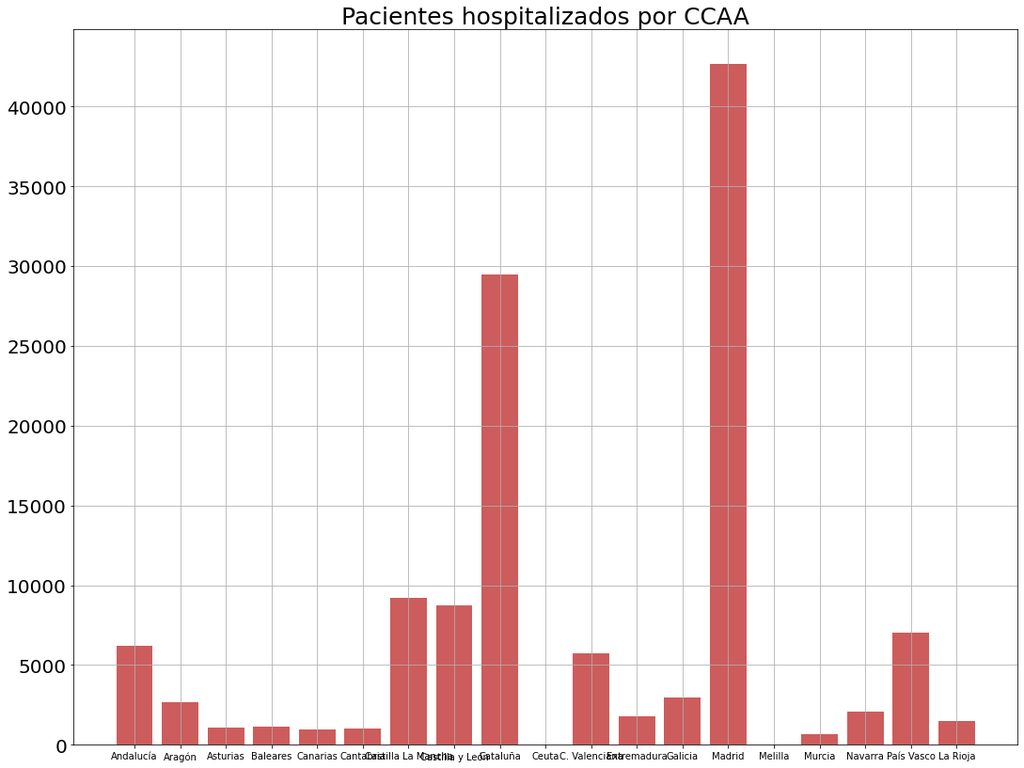

```python
graficas(hospitalizados.CCAA,hospitalizados.total, "Pacientes hospitalizados por CCAA")
```

- 1. Predicciones sobre los datos

Una vez llegados a este punto nos planteamos la siguente pregunta **¿Cuantos fallecimientos se hubieran producido si se hubiera infectado el 100% de la poblacion en españa?**

La pregunta se plantea como comparativa del número de fallecimientos con las restricciones de movilidad que hemos tenido y si por el contrario no las hubiesemos tenido y se hubiera infectado la totalidad de la población. Para resolver esta pregunta decidimos crear un Algoritmo de Machine Learning utilizando un dataframe con datos a nivel nacional.

```python
# Utilizaramemos el DataFrame "nacional", este recoge todos los datos disponibles a nivel Nacional del Covid-19
nacional.head(20)
```

|  | fecha | casos_total | casos_pcr | casos_test_ac | altas | fallecimientos | ingresos_uci | hospitalizados |
| --- | --- | --- | --- | --- | --- | --- | --- | --- |
| 0 | 2020-02-21 | 3.0 | 3 | NaN | NaN | NaN | NaN | NaN |
| 1 | 2020-02-22 | 3.0 | 3 | NaN | NaN | NaN | NaN | NaN |
| 2 | 2020-02-23 | 3.0 | 3 | NaN | NaN | NaN | NaN | NaN |
| 3 | 2020-02-24 | 3.0 | 3 | NaN | NaN | NaN | NaN | NaN |
| 4 | 2020-02-25 | 4.0 | 4 | NaN | NaN | NaN | NaN | NaN |
| 5 | 2020-02-26 | 10.0 | 10 | NaN | NaN | NaN | NaN | NaN |
| 6 | 2020-02-27 | 18.0 | 18 | NaN | NaN | NaN | NaN | NaN |
| 7 | 2020-02-28 | 36.0 | 36 | NaN | NaN | NaN | NaN | NaN |
| 8 | 2020-02-29 | 55.0 | 55 | NaN | NaN | NaN | NaN | NaN |
| 9 | 2020-03-01 | 83.0 | 83 | NaN | NaN | NaN | NaN | NaN |
| 10 | 2020-03-02 | 138.0 | 138 | NaN | NaN | NaN | NaN | NaN |
| 11 | 2020-03-03 | 195.0 | 195 | NaN | NaN | NaN | NaN | NaN |
| 12 | 2020-03-04 | 269.0 | 269 | NaN | NaN | 1.0 | NaN | NaN |
| 13 | 2020-03-05 | 351.0 | 351 | NaN | NaN | 3.0 | NaN | NaN |
| 14 | 2020-03-06 | 533.0 | 533 | NaN | NaN | 5.0 | NaN | NaN |
| 15 | 2020-03-07 | 768.0 | 768 | NaN | NaN | 8.0 | NaN | NaN |
| 16 | 2020-03-08 | 1100.0 | 1100 | NaN | NaN | 17.0 | NaN | NaN |
| 17 | 2020-03-09 | 1535.0 | 1535 | NaN | 24.0 | 28.0 | NaN | NaN |
| 18 | 2020-03-10 | 2302.0 | 2302 | NaN | 138.0 | 35.0 | NaN | NaN |
| 19 | 2020-03-11 | 3279.0 | 3279 | NaN | 188.0 | 48.0 | NaN | NaN |

```python
# Sustituimos los valores NaN por 0, pues los dias que los datos han sido NaN(desconocidos), se han contabilizado y acumulado a dias posteriores

nacional= nacional.fillna(0)
nacional.head(30)
```

|  | fecha | casos_total | casos_pcr | casos_test_ac | altas | fallecimientos | ingresos_uci | hospitalizados |
| --- | --- | --- | --- | --- | --- | --- | --- | --- |
| 0 | 2020-02-21 | 3.0 | 3 | 0.0 | 0.0 | 0.0 | 0.0 | 0.0 |
| 1 | 2020-02-22 | 3.0 | 3 | 0.0 | 0.0 | 0.0 | 0.0 | 0.0 |
| 2 | 2020-02-23 | 3.0 | 3 | 0.0 | 0.0 | 0.0 | 0.0 | 0.0 |
| 3 | 2020-02-24 | 3.0 | 3 | 0.0 | 0.0 | 0.0 | 0.0 | 0.0 |
| 4 | 2020-02-25 | 4.0 | 4 | 0.0 | 0.0 | 0.0 | 0.0 | 0.0 |
| 5 | 2020-02-26 | 10.0 | 10 | 0.0 | 0.0 | 0.0 | 0.0 | 0.0 |
| 6 | 2020-02-27 | 18.0 | 18 | 0.0 | 0.0 | 0.0 | 0.0 | 0.0 |
| 7 | 2020-02-28 | 36.0 | 36 | 0.0 | 0.0 | 0.0 | 0.0 | 0.0 |
| 8 | 2020-02-29 | 55.0 | 55 | 0.0 | 0.0 | 0.0 | 0.0 | 0.0 |
| 9 | 2020-03-01 | 83.0 | 83 | 0.0 | 0.0 | 0.0 | 0.0 | 0.0 |
| 10 | 2020-03-02 | 138.0 | 138 | 0.0 | 0.0 | 0.0 | 0.0 | 0.0 |
| 11 | 2020-03-03 | 195.0 | 195 | 0.0 | 0.0 | 0.0 | 0.0 | 0.0 |
| 12 | 2020-03-04 | 269.0 | 269 | 0.0 | 0.0 | 1.0 | 0.0 | 0.0 |
| 13 | 2020-03-05 | 351.0 | 351 | 0.0 | 0.0 | 3.0 | 0.0 | 0.0 |
| 14 | 2020-03-06 | 533.0 | 533 | 0.0 | 0.0 | 5.0 | 0.0 | 0.0 |
| 15 | 2020-03-07 | 768.0 | 768 | 0.0 | 0.0 | 8.0 | 0.0 | 0.0 |
| 16 | 2020-03-08 | 1100.0 | 1100 | 0.0 | 0.0 | 17.0 | 0.0 | 0.0 |
| 17 | 2020-03-09 | 1535.0 | 1535 | 0.0 | 24.0 | 28.0 | 0.0 | 0.0 |
| 18 | 2020-03-10 | 2302.0 | 2302 | 0.0 | 138.0 | 35.0 | 0.0 | 0.0 |
| 19 | 2020-03-11 | 3279.0 | 3279 | 0.0 | 188.0 | 48.0 | 0.0 | 0.0 |
| 20 | 2020-03-12 | 4433.0 | 4433 | 0.0 | 202.0 | 85.0 | 0.0 | 0.0 |
| 21 | 2020-03-13 | 5955.0 | 5955 | 0.0 | 212.0 | 124.0 | 0.0 | 0.0 |
| 22 | 2020-03-14 | 7646.0 | 7646 | 0.0 | 555.0 | 144.0 | 0.0 | 0.0 |
| 23 | 2020-03-15 | 9786.0 | 9786 | 0.0 | 567.0 | 296.0 | 0.0 | 0.0 |
| 24 | 2020-03-16 | 11488.0 | 11488 | 0.0 | 586.0 | 318.0 | 0.0 | 0.0 |
| 25 | 2020-03-17 | 14011.0 | 14011 | 0.0 | 913.0 | 497.0 | 0.0 | 0.0 |
| 26 | 2020-03-18 | 17707.0 | 17707 | 0.0 | 971.0 | 591.0 | 0.0 | 0.0 |
| 27 | 2020-03-19 | 21744.0 | 21744 | 0.0 | 1210.0 | 766.0 | 0.0 | 0.0 |
| 28 | 2020-03-20 | 26299.0 | 26299 | 0.0 | 1542.0 | 995.0 | 0.0 | 0.0 |
| 29 | 2020-03-21 | 31765.0 | 31765 | 0.0 | 2133.0 | 1349.0 | 0.0 | 0.0 |

```python
# Eliminamos del DataFrame la columna de fecha pues no la utilizaremos para este caso
df_nacional= nacional.drop(["fecha"], axis=1)
```

```python
# Resumen estadistico
df_nacional.describe()
```

|  | casos_total | casos_pcr | casos_test_ac | altas | fallecimientos | ingresos_uci | hospitalizados |
| --- | --- | --- | --- | --- | --- | --- | --- |
| count | 237.000000 | 2.370000e+02 | 237.000000 | 237.000000 | 237.000000 | 237.000000 | 237.000000 |
| mean | 50539.075949 | 3.989589e+05 | 4412.388186 | 18954.029536 | 23800.611814 | 8846.556962 | 98240.822785 |
| std | 92094.938397 | 3.960787e+05 | 11752.983689 | 40822.584673 | 11670.308009 | 5794.052683 | 63818.653951 |
| min | 0.000000 | 3.000000e+00 | 0.000000 | 0.000000 | 0.000000 | 0.000000 | 0.000000 |
| 25% | 0.000000 | 1.957460e+05 | 0.000000 | 0.000000 | 20851.000000 | 0.000000 | 0.000000 |
| 50% | 0.000000 | 2.452680e+05 | 0.000000 | 0.000000 | 28323.000000 | 11630.000000 | 124779.000000 |
| 75% | 41263.000000 | 4.885130e+05 | 0.000000 | 1542.000000 | 29234.000000 | 12380.000000 | 135174.000000 |
| max | 280117.000000 | 1.594844e+06 | 47080.000000 | 150376.000000 | 43668.000000 | 15898.000000 | 186346.000000 |

```python
# Realizamos una seleccion "FEUTURE SELECCTION" con las mejores, utilizamos las variables que mas aportan

X=df_nacional.drop(['fallecimientos'], axis=1)
y=df_nacional['fallecimientos']

best=SelectKBest(k=5)
X_new = best.fit_transform(X, y)
X_new.shape
selected = best.get_support(indices=True)
a = X.columns[selected]
print(a)
```

```
Index(['casos_total', 'casos_test_ac', 'altas', 'ingresos_uci',
       'hospitalizados'],
      dtype='object')
```

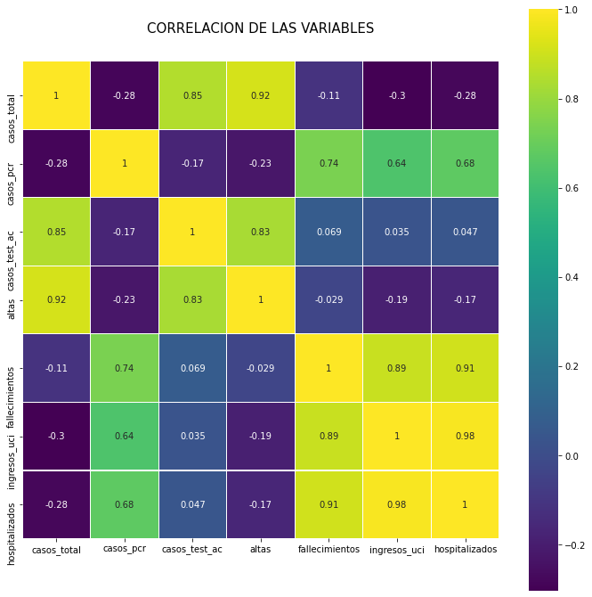

```python
# Observamos la correlación

colormap = plt.cm.viridis
plt.figure(figsize=(12,12))
plt.title('CORRELACION DE LAS VARIABLES', y=1.05, size=15)
sb.heatmap(df_nacional.corr(),linewidths=0.1,vmax=1.0, square=True, cmap=colormap, linecolor='white', annot=True)
```

Para nuestro ejercicio de prediccion hemos decidido emplear un algoritmo de **regresion lineal simple**, con una variable X independiente (casos_pcr) y una variable Y dependiente (fallecimientos). Aunque la variable "casos_pcr quedó fuera en la Feuture Selecction observamos que su correlacion con los fallecimientos es del 0.74 y esperemos que sea suficiente, pues nos interesa conocer el resultado de los fallecimientos sobre una variable que se pudiera aplicar de manera inequivoca en caso de uso real en crivado masivo de la población con pcr´s)

```python
# Asignamos nuestra variable de entrada X para entrenamiento y las etiquetas Y.
dataX = df_nacional[["casos_pcr"]]
X_train = np.array(dataX)
y_train = df_nacional['fallecimientos'].values
```

```python
# Creamos el objeto de Regresión Linear
regr = LinearRegression()
```

```python
regr.fit(X_train, y_train)
```

```
LinearRegression()
```

```python
y_pred = regr.predict(X_train)
```

```python
# Veamos los coeficienetes obtenidos
print('Coefficients: \n', regr.coef_)
# Este es el valor donde corta el eje Y (en X=0)
print('Independent term: \n', regr.intercept_)
```

```
Coefficients:
 [0.02166182]
Independent term:
 15158.43644731569
```

```python
# Queremos predecir cuántos "Fallecidos" tendriamos con 47.000.000 de personas contagiadas por Covid-19 con test de antigenos realizados positivos,

y_covid = regr.predict([[47000000]])
print("Para el total de la poblacion española infectada con pcr positivo tendriamos",int(y_covid),"fallecimientos")
```

```
Para el total de la poblacion española infectada con pcr positivo tendriamos 1033263 fallecimientos
```

#### Conclusion:

Según nuestro estudio si toda la población Española estuviera infectada, con confirmación por pcr, de Covid-19 **los fallecimientos ascenderían a aproximadamente 1 millon de personas**, por lo que entendemos que las medidad de restricción de la movilidad han reducido enormemente el impacto sobre los fallecimientos en la población.

- 1. Predicciones sobre series temporales

Para nuestras predicciones sobre series temporales hemos decidido utilizar **Prophet** se trata de un modelo aditivo en el que las tendencias no lineales se ajustan a la estacionalidad anual, semanal y diaria, además de los efectos de las vacaciones. Funciona mejor con series de tiempo que tienen fuertes efectos estacionales y varias temporadas de datos históricos. Prophet es robusto ante los datos faltantes y los cambios en la tendencia, y normalmente maneja bien los valores atípicos.

Prophet es un software de código abierto lanzado por el equipo Core Data Science de Facebook

```
INFO:fbprophet:Disabling yearly seasonality. Run prophet with yearly_seasonality=True to override this.
INFO:fbprophet:Disabling daily seasonality. Run prophet with daily_seasonality=True to override this.
```

```
 Prediccion de infectados
```

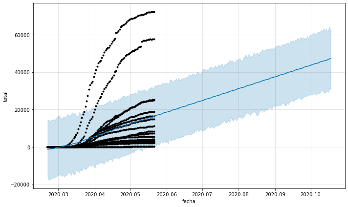

```python
# Descargamos la libreria
from fbprophet import Prophet

# Creamos un dataframe con las dos columnas ds e y para nuestro modelo sobre el df de infectados
covid_cc=infectados.loc[:,["fecha","total"]]
covid_cc['ds']=covid_cc['fecha']
covid_cc['y']=covid_cc['total']
covid_cc.drop(columns=['fecha','total'], inplace=True)
covid_cc.head()
# Creamos el modelo
model_cc=Prophet()
model_cc.fit(covid_cc)
# Indicamos la preddicción y los periodos a predecir
future = model_cc.make_future_dataframe(periods=150)
forecast=model_cc.predict(future)
print(" Prediccion de infectados ")
fig_Confirmed = model_cc.plot(forecast,xlabel = "fecha",ylabel = "total")
```

```
visializamos los componentes del pronostico
```

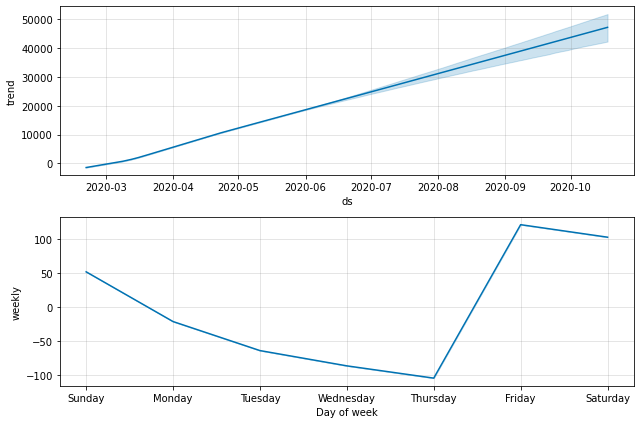

```python
print("visializamos los componentes del pronostico")
fig = model_cc.plot_components(forecast)
```

```
INFO:fbprophet:Disabling yearly seasonality. Run prophet with yearly_seasonality=True to override this.
INFO:fbprophet:Disabling daily seasonality. Run prophet with daily_seasonality=True to override this.
```

```
 Prediccion de ingresos en uci
```

[figure not shown]

```python
# Creamos un dataframe con las dos columnas "ds" e "y" para nuestro modelo sobre el df nacional
covid_cc2=nacional.loc[:,["fecha","ingresos_uci"]]
covid_cc2['ds']=covid_cc2["fecha"]
covid_cc2['y']=covid_cc2['ingresos_uci']
covid_cc2.drop(columns=['fecha','ingresos_uci'], inplace=True)
covid_cc2.head()
# Creamos el modelo
model_cc2=Prophet()
model_cc2.fit(covid_cc2)
# Indicamos la preddicción y los periodos a predecir
future = model_cc2.make_future_dataframe(periods=150)
forecast=model_cc2.predict(future)
print(" Prediccion de ingresos en uci ")
fig_Confirmed = model_cc2.plot(forecast,xlabel = "fecha",ylabel = "ingresos_uci")
```

```
visializamos los componentes del pronostico
```

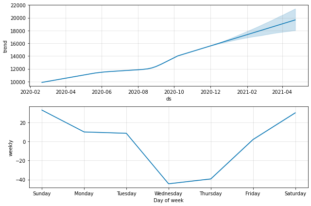

```python
print("visializamos los componentes del pronostico")
fig = model_cc2.plot_components(forecast)
```

```
INFO:fbprophet:Disabling yearly seasonality. Run prophet with yearly_seasonality=True to override this.
INFO:fbprophet:Disabling daily seasonality. Run prophet with daily_seasonality=True to override this.
```

```
 Prediccion de fallecimientos
```

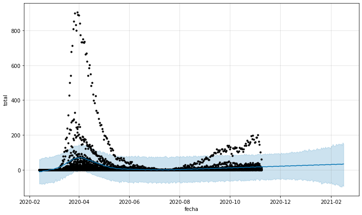

```python
# Creamos un dataframe con las dos columnas "ds" e "y" para nuestro modelo sobre el df fallecimientos
covid_cc3=fallecidos.loc[:,["fecha","total"]]
covid_cc3['ds']=covid_cc3["fecha"]
covid_cc3['y']=covid_cc3['total']
covid_cc3.drop(columns=['fecha','total'], inplace=True)
covid_cc3.head()
# Creamos el modelo
model_cc3=Prophet()
model_cc3.fit(covid_cc3)
# Indicamos la preddicción y los periodos a predecir
future = model_cc3.make_future_dataframe(periods=100)
forecast=model_cc3.predict(future)
print(" Prediccion de fallecimientos ")
fig_Confirmed = model_cc3.plot(forecast,xlabel = "fecha",ylabel = "total")
```

```
visializamos los componentes del pronostico
```

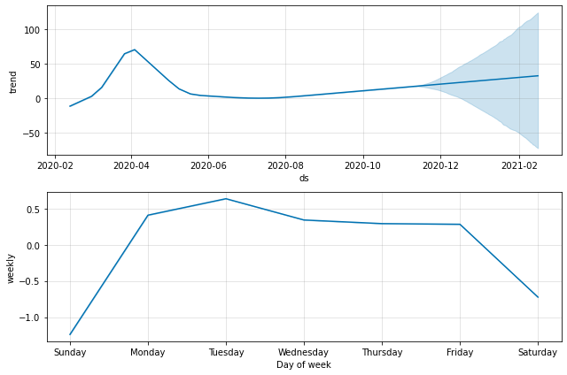

```python
print("visializamos los componentes del pronostico")
fig = model_cc3.plot_components(forecast)
```

#### Conclusion:

Como hemos podido observar hemos realizado pronosticos sobre algunas variables que nos parecen interesantes, el pronostico en series temporales es muy útil para predecir lo que puede ocurrir, y asi adelantarnos en la previsión, es del todo interesante para el uso en casos empresariales y predecir nuestras ventas y por tanto nuestras compras, por ejemplo, así como para resolver incognitas en casos que afectan a la sociedad, en este caso que abarcamos podríamos predecir en numero de casos positivos por pcr y asi delantar la provisión de este tipo de test con meses de adelanto.

- 1. Analisis de sentimientos en la red social Twitter sobre la reciente vacuna para el Covid-19

Decidimos capturar tweets a nivel nacional que contengan el contenido que deseamos sobre la vacuna del covid-19, y tras su captura, decidimos hacer un **analisis de sentimientos** de los datos obtenidos.

```python
#Descargamos la libreria Tweepy para el ejercicio y Json por si decidimos visualizarlo en ese formato
import tweepy
import csv
from datetime import datetime
from textblob import TextBlob
```

```python
#Autenticacion de usuario
consumer_key = "mlkC3QCI1A5nXAfwHbVQ4mOra"
consumer_secret = "IIwQFMdkiY2kR9QVWu2DJrpHXa2hG6BdSlz33rY5u7k9OS95ys"
access_token = "1261955199784103936-5Ze0m3EB4kb2OOa2XP0vW8dqFf7mUR"
access_token_secret = "JX1EGo8iODsc6tEpXwQstkn9FoMsNi4wyXWQnFbCrjxbA"
```

```python
#Se autentica en twitter
auth = tweepy.OAuthHandler(consumer_key, consumer_secret)
auth.set_access_token(access_token, access_token_secret)
api = tweepy.API(auth)
```

```python
auth = tweepy.OAuthHandler(consumer_key, consumer_secret)
auth.set_access_token(access_token, access_token_secret)
```

```python
#Se pregunta por la palabra a preguntar
palabra = input("Buscar: ")
```

```
Buscar: vacuna
```

```python
#Se define la cantida de tweets a capturar
numero_de_Tweets = int(input("Número de tweets a capturar: "))
```

```
Número de tweets a capturar: 2000
```

```python
#Se define el idioma de los tweets a analizar
lenguaje = input("Idioma [es/en]:")
```

```
Idioma [es/en]:es
```

```python
def ObtenerTweets(palabra="vacuna",times=2000,leguanje="es"):
    #Se define las listas que capturan la popularidad
    popularidad_list = []
    numeros_list = []
    numero = 1
    for tweet in tweepy.Cursor(api.search, palabra, lang=lenguaje).items(numero_de_Tweets):
        try:
            #Se toma el texto, se hace el analisis de sentimiento
            #y se agrega el resultado a las listas
            analisis = TextBlob(tweet.text)
            analisis = analisis.sentiment
            popularidad = analisis.polarity
            popularidad_list.append(popularidad)
            numeros_list.append(numero)
            numero = numero + 1

        except tweepy.TweepError as e:
            print(e.reason)

        except StopIteration:
            break
    return (numeros_list,popularidad_list,numero)
```

```python
def GraficarDatos(numeros_list,popularidad_list,numero):
    axes = plt.gca()
    axes.set_ylim([-1, 1.5])

    plt.scatter(numeros_list, popularidad_list)
    popularidadPromedio = (sum(popularidad_list))/(len(popularidad_list))
    popularidadPromedio = "{0:.0f}%".format(popularidadPromedio * 100)
    time  = datetime.now().strftime("A : %H:%M\n El: %m-%d-%y")
    plt.text(0, 1.25,
             "Sentimiento promedio:  " + str(popularidadPromedio) + "\n" + time,
             fontsize=6,
             bbox = dict(facecolor='none',
                         edgecolor='black',
                         boxstyle='square, pad = 1'))

    plt.title("Sentimientos sobre " + palabra + " en twitter")
    plt.xlabel("Numero de tweets")
    plt.ylabel("Sentimiento")
    plt.show()
```

```python
numeros_list,popularidad_list,numero = ObtenerTweets(palabra,numero_de_Tweets,lenguaje)
```

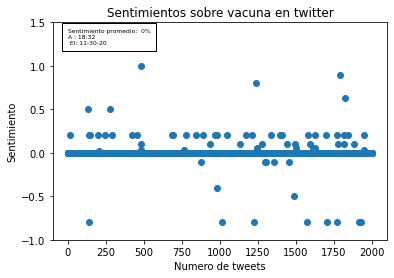

```python
GraficarDatos(numeros_list,popularidad_list,numero)
```

#### Conclusiones:

(*Tenemos en cuenta que en la fecha de captura de los tweets (Lunes 30 de Noviembre 2020) la empresa Europea Modena anunció la efectividad del 94% en su vacuna y solicitó permiso para su comercialización*)